# Project

```python
import pandas as pd
import numpy as np
import seaborn as sn
import scipy.stats as st
import matplotlib.pyplot as plt
from matplotlib import style
import xgboost as xgb
from sklearn.ensemble import RandomForestRegressor
from sklearn.model_selection import train_test_split
from sklearn.metrics import mean_absolute_error, mean_squared_error, r2_score, mean_absolute_percentage_error
%matplotlib inline
import random
import math
import datetime
import warnings
warnings.filterwarnings('ignore')
```

```python
data = pd.read_csv('sales_data_py_project.csv')
data.head()
```

|  | Row ID | Order ID | Order Date | Ship Date | Ship Mode | Customer ID | Customer Name | Segment | Country | City | ... | Postal Code | Region | Product ID | Category | Sub-Category | Product Name | Sales | Quantity | Discount | Profit |
| --- | --- | --- | --- | --- | --- | --- | --- | --- | --- | --- | --- | --- | --- | --- | --- | --- | --- | --- | --- | --- | --- |
| 0 | 1 | CA-2013-152156 | 11/9/2013 | 11/12/2013 | Second Class | CG-12520 | Claire Gute | Consumer | United States | Henderson | ... | 42420 | South | FUR-BO-10001798 | Furniture | Bookcases | Bush Somerset Collection Bookcase | 261.9600 | 2 | 0.00 | 41.9136 |
| 1 | 2 | CA-2013-152156 | 11/9/2013 | 11/12/2013 | Second Class | CG-12520 | Claire Gute | Consumer | United States | Henderson | ... | 42420 | South | FUR-CH-10000454 | Furniture | Chairs | Hon Deluxe Fabric Upholstered Stacking Chairs,... | 731.9400 | 3 | 0.00 | 219.5820 |
| 2 | 3 | CA-2013-138688 | 6/13/2013 | 6/17/2013 | Second Class | DV-13045 | Darrin Van Huff | Corporate | United States | Los Angeles | ... | 90036 | West | OFF-LA-10000240 | Office Supplies | Labels | Self-Adhesive Address Labels for Typewriters b... | 14.6200 | 2 | 0.00 | 6.8714 |
| 3 | 4 | US-2012-108966 | 10/11/2012 | 10/18/2012 | Standard Class | SO-20335 | Sean O'Donnell | Consumer | United States | Fort Lauderdale | ... | 33311 | South | FUR-TA-10000577 | Furniture | Tables | Bretford CR4500 Series Slim Rectangular Table | 957.5775 | 5 | 0.45 | -383.0310 |
| 4 | 5 | US-2012-108966 | 10/11/2012 | 10/18/2012 | Standard Class | SO-20335 | Sean O'Donnell | Consumer | United States | Fort Lauderdale | ... | 33311 | South | OFF-ST-10000760 | Office Supplies | Storage | Eldon Fold 'N Roll Cart System | 22.3680 | 2 | 0.20 | 2.5164 |

5 rows × 21 columns

```python
data.shape
```

```
(9994, 21)
```

```python
data.info()
```

```
<class 'pandas.core.frame.DataFrame'>
RangeIndex: 9994 entries, 0 to 9993
Data columns (total 21 columns):
 #   Column         Non-Null Count  Dtype
---  ------         --------------  -----
 0   Row ID         9994 non-null   int64
 1   Order ID       9994 non-null   object
 2   Order Date     9994 non-null   object
 3   Ship Date      9994 non-null   object
 4   Ship Mode      9972 non-null   object
 5   Customer ID    9994 non-null   object
 6   Customer Name  9994 non-null   object
 7   Segment        9985 non-null   object
 8   Country        9988 non-null   object
 9   City           9994 non-null   object
 10  State          9994 non-null   object
 11  Postal Code    9994 non-null   int64
 12  Region         9978 non-null   object
 13  Product ID     9994 non-null   object
 14  Category       9994 non-null   object
 15  Sub-Category   9994 non-null   object
 16  Product Name   9994 non-null   object
 17  Sales          9994 non-null   float64
 18  Quantity       9994 non-null   int64
 19  Discount       9994 non-null   float64
 20  Profit         9994 non-null   float64
dtypes: float64(3), int64(3), object(15)
memory usage: 1.6+ MB
```

```python
data.describe()
```

|  | Row ID | Postal Code | Sales | Quantity | Discount | Profit |
| --- | --- | --- | --- | --- | --- | --- |
| count | 9994.000000 | 9994.000000 | 9994.000000 | 9994.000000 | 9994.000000 | 9994.000000 |
| mean | 4997.500000 | 55190.379428 | 229.858001 | 3.789574 | 0.156203 | 28.656896 |
| std | 2885.163629 | 32063.693350 | 623.245101 | 2.225110 | 0.206452 | 234.260108 |
| min | 1.000000 | 1040.000000 | 0.444000 | 1.000000 | 0.000000 | -6599.978000 |
| 25% | 2499.250000 | 23223.000000 | 17.280000 | 2.000000 | 0.000000 | 1.728750 |
| 50% | 4997.500000 | 56430.500000 | 54.490000 | 3.000000 | 0.200000 | 8.666500 |
| 75% | 7495.750000 | 90008.000000 | 209.940000 | 5.000000 | 0.200000 | 29.364000 |
| max | 9994.000000 | 99301.000000 | 22638.480000 | 14.000000 | 0.800000 | 8399.976000 |

```python
data.nunique()
```

```
Row ID           9994
Order ID         5009
Order Date       1238
Ship Date        1334
Ship Mode           4
Customer ID       793
Customer Name     793
Segment             3
Country             1
City              531
State              49
Postal Code       631
Region              4
Product ID       1862
Category            3
Sub-Category       17
Product Name     1850
Sales            5825
Quantity           14
Discount           12
Profit           7287
dtype: int64
```

```python
data.isnull().sum().sort_values(ascending=False)
```

```
Ship Mode        22
Region           16
Segment           9
Country           6
Row ID            0
Discount          0
Quantity          0
Sales             0
Product Name      0
Sub-Category      0
Category          0
Product ID        0
State             0
Postal Code       0
Order ID          0
City              0
Customer Name     0
Customer ID       0
Ship Date         0
Order Date        0
Profit            0
dtype: int64
```

```python
data['Order Date']=pd.to_datetime(data['Order Date'])
print(data['Order Date'])
```

```
0      2013-11-09
1      2013-11-09
2      2013-06-13
3      2012-10-11
4      2012-10-11
          ...
9989   2011-01-22
9990   2014-02-27
9991   2014-02-27
9992   2014-02-27
9993   2014-05-05
Name: Order Date, Length: 9994, dtype: datetime64[ns]
```

```python
data['Ship Date']=pd.to_datetime(data['Ship Date'])
print(data['Ship Date'])
```

```
0      2013-11-12
1      2013-11-12
2      2013-06-17
3      2012-10-18
4      2012-10-18
          ...
9989   2011-01-24
9990   2014-03-04
9991   2014-03-04
9992   2014-03-04
9993   2014-05-10
Name: Ship Date, Length: 9994, dtype: datetime64[ns]
```

```python
data.head()
```

|  | Row ID | Order ID | Order Date | Ship Date | Ship Mode | Customer ID | Customer Name | Segment | Country | City | ... | Postal Code | Region | Product ID | Category | Sub-Category | Product Name | Sales | Quantity | Discount | Profit |
| --- | --- | --- | --- | --- | --- | --- | --- | --- | --- | --- | --- | --- | --- | --- | --- | --- | --- | --- | --- | --- | --- |
| 0 | 1 | CA-2013-152156 | 2013-11-09 | 2013-11-12 | Second Class | CG-12520 | Claire Gute | Consumer | United States | Henderson | ... | 42420 | South | FUR-BO-10001798 | Furniture | Bookcases | Bush Somerset Collection Bookcase | 261.9600 | 2 | 0.00 | 41.9136 |
| 1 | 2 | CA-2013-152156 | 2013-11-09 | 2013-11-12 | Second Class | CG-12520 | Claire Gute | Consumer | United States | Henderson | ... | 42420 | South | FUR-CH-10000454 | Furniture | Chairs | Hon Deluxe Fabric Upholstered Stacking Chairs,... | 731.9400 | 3 | 0.00 | 219.5820 |
| 2 | 3 | CA-2013-138688 | 2013-06-13 | 2013-06-17 | Second Class | DV-13045 | Darrin Van Huff | Corporate | United States | Los Angeles | ... | 90036 | West | OFF-LA-10000240 | Office Supplies | Labels | Self-Adhesive Address Labels for Typewriters b... | 14.6200 | 2 | 0.00 | 6.8714 |
| 3 | 4 | US-2012-108966 | 2012-10-11 | 2012-10-18 | Standard Class | SO-20335 | Sean O'Donnell | Consumer | United States | Fort Lauderdale | ... | 33311 | South | FUR-TA-10000577 | Furniture | Tables | Bretford CR4500 Series Slim Rectangular Table | 957.5775 | 5 | 0.45 | -383.0310 |
| 4 | 5 | US-2012-108966 | 2012-10-11 | 2012-10-18 | Standard Class | SO-20335 | Sean O'Donnell | Consumer | United States | Fort Lauderdale | ... | 33311 | South | OFF-ST-10000760 | Office Supplies | Storage | Eldon Fold 'N Roll Cart System | 22.3680 | 2 | 0.20 | 2.5164 |

5 rows × 21 columns

```python
data.drop('Country', axis=1, inplace = True)  #dropped the country and Postal Code columns
data.drop('Postal Code', axis=1, inplace = True)
```

```python
data.count()
```

```
Row ID           9994
Order ID         9994
Order Date       9994
Ship Date        9994
Ship Mode        9972
Customer ID      9994
Customer Name    9994
Segment          9985
City             9994
State            9994
Region           9978
Product ID       9994
Category         9994
Sub-Category     9994
Product Name     9994
Sales            9994
Quantity         9994
Discount         9994
Profit           9994
dtype: int64
```

```python
data=data.sort_values(by=['State','Region'], na_position ='last')
data['Region']=data['Region'].ffill()
```

```python
data.isnull().sum().sort_values(ascending=False)
```

```
Ship Mode        22
Segment           9
Row ID            0
Product ID        0
Discount          0
Quantity          0
Sales             0
Product Name      0
Sub-Category      0
Category          0
State             0
Region            0
Order ID          0
City              0
Customer Name     0
Customer ID       0
Ship Date         0
Order Date        0
Profit            0
dtype: int64
```

```python
data=data.sort_values(['Customer ID','Segment'],na_position ='last')
data['Segment']=data['Segment'].ffill()
data.isna().sum().sort_values(ascending=False)
```

```
Ship Mode        22
Row ID            0
Region            0
Discount          0
Quantity          0
Sales             0
Product Name      0
Sub-Category      0
Category          0
Product ID        0
State             0
Order ID          0
City              0
Segment           0
Customer Name     0
Customer ID       0
Ship Date         0
Order Date        0
Profit            0
dtype: int64
```

```python
data['Ship Mode'].value_counts()
```

```
Standard Class    5957
Second Class      1940
First Class       1534
Same Day           541
Name: Ship Mode, dtype: int64
```

```python
data=data.sort_values(by=['Order Date','Customer ID','Ship Mode'],na_position ='last')
data['Ship Mode']=data['Ship Mode'].ffill()
data.isna().sum()
```

```
Row ID           0
Order ID         0
Order Date       0
Ship Date        0
Ship Mode        0
Customer ID      0
Customer Name    0
Segment          0
City             0
State            0
Region           0
Product ID       0
Category         0
Sub-Category     0
Product Name     0
Sales            0
Quantity         0
Discount         0
Profit           0
dtype: int64
```

```python
data.info()
```

```
<class 'pandas.core.frame.DataFrame'>
Int64Index: 9994 entries, 7980 to 908
Data columns (total 19 columns):
 #   Column         Non-Null Count  Dtype
---  ------         --------------  -----
 0   Row ID         9994 non-null   int64
 1   Order ID       9994 non-null   object
 2   Order Date     9994 non-null   datetime64[ns]
 3   Ship Date      9994 non-null   datetime64[ns]
 4   Ship Mode      9994 non-null   object
 5   Customer ID    9994 non-null   object
 6   Customer Name  9994 non-null   object
 7   Segment        9994 non-null   object
 8   City           9994 non-null   object
 9   State          9994 non-null   object
 10  Region         9994 non-null   object
 11  Product ID     9994 non-null   object
 12  Category       9994 non-null   object
 13  Sub-Category   9994 non-null   object
 14  Product Name   9994 non-null   object
 15  Sales          9994 non-null   float64
 16  Quantity       9994 non-null   int64
 17  Discount       9994 non-null   float64
 18  Profit         9994 non-null   float64
dtypes: datetime64[ns](2), float64(3), int64(2), object(12)
memory usage: 1.5+ MB
```

# Exploratory Data Analysis

# Product Analysis:

## Different types of product categories

```python
data['Category'].value_counts()
```

```
Office Supplies    6026
Furniture          2121
Technology         1847
Name: Category, dtype: int64
```

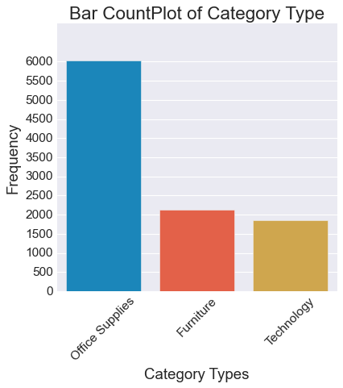

```python
plt.figure(figsize=(5,5))
sn.countplot(x='Category', data=data)
plt.title('Bar CountPlot of Category Type')
plt.xlabel('Category Types')
plt.ylabel('Frequency')
plt.xticks(rotation=45)
plt.yticks(np.arange(0, 6500,500))
plt.show()
```

```python
data.Category.value_counts(normalize=True)
```

```
Office Supplies    0.602962
Furniture          0.212227
Technology         0.184811
Name: Category, dtype: float64
```

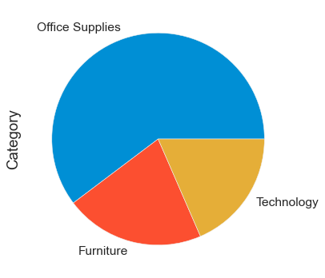

```python
plt.figure(figsize=(5,5))
data.Category.value_counts(normalize=True)
data.Category.value_counts(normalize=True).plot.pie()
plt.show()
```

Noticed that 'Office Supplies' is the best-selling Category.

```python
Sales = data.groupby(['Category'])['Sales'].sum().sort_values(ascending = False)
Sales = Sales.to_frame(name='Sales').reset_index()
Sales
```

|  | Category | Sales |
| --- | --- | --- |
| 0 | Technology | 836154.0330 |
| 1 | Furniture | 741999.7953 |
| 2 | Office Supplies | 719047.0320 |

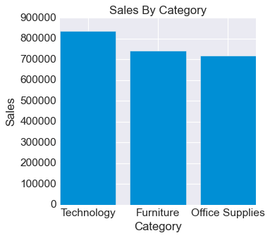

```python
plt.figure(figsize=(4,4))
plt.bar(Sales['Category'], Sales['Sales'])

plt.title('Sales By Category', fontsize = 15)
plt.xlabel('Category', fontsize = 15)
plt.ylabel('Sales', fontsize = 15)
plt.show()
```

```python
Qty = data.groupby(['Category'])['Quantity'].sum().sort_values(ascending = False)
Qty = Qty.to_frame(name='Quantity').reset_index()
Qty
```

|  | Category | Quantity |
| --- | --- | --- |
| 0 | Office Supplies | 22906 |
| 1 | Furniture | 8028 |
| 2 | Technology | 6939 |

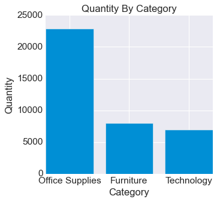

```python
plt.figure(figsize=(4,4))
plt.bar(Qty['Category'], Qty['Quantity'])

plt.title('Quantity By Category', fontsize = 15)
plt.xlabel('Category', fontsize = 15)
plt.ylabel('Quantity', fontsize = 15)
plt.show()
```

## Various subcategories of products

```python
data['Sub-Category'].value_counts()
```

```
Binders        1523
Paper          1370
Furnishings     957
Phones          889
Storage         846
Art             796
Accessories     775
Chairs          617
Appliances      466
Labels          364
Tables          319
Envelopes       254
Bookcases       228
Fasteners       217
Supplies        190
Machines        115
Copiers          68
Name: Sub-Category, dtype: int64
```

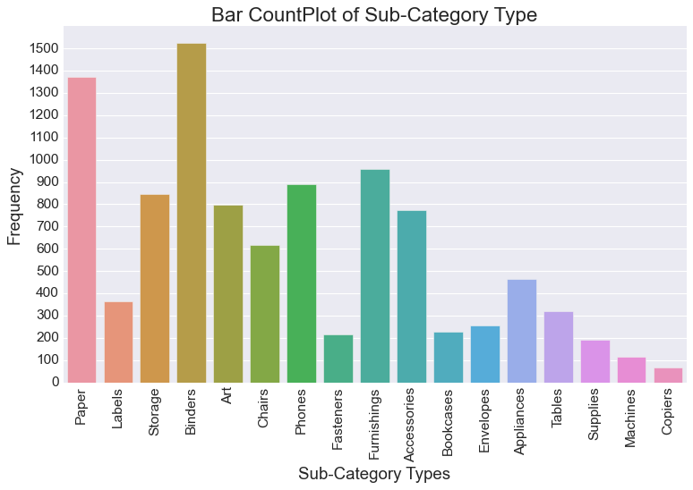

```python
plt.figure(figsize=(10,6))
sn.countplot(x='Sub-Category', data=data)
plt.title('Bar CountPlot of Sub-Category Type')
plt.xlabel('Sub-Category Types')
plt.ylabel('Frequency')
plt.xticks(rotation=90)
plt.yticks(np.arange(0, 1600,100))
plt.show()
```

```python
data['Profit'].value_counts()
```

```
0.0000      65
6.2208      43
9.3312      38
3.6288      32
5.4432      32
            ..
209.2740     1
2.1476       1
106.1242     1
8.5372       1
19.7910      1
Name: Profit, Length: 7287, dtype: int64
```

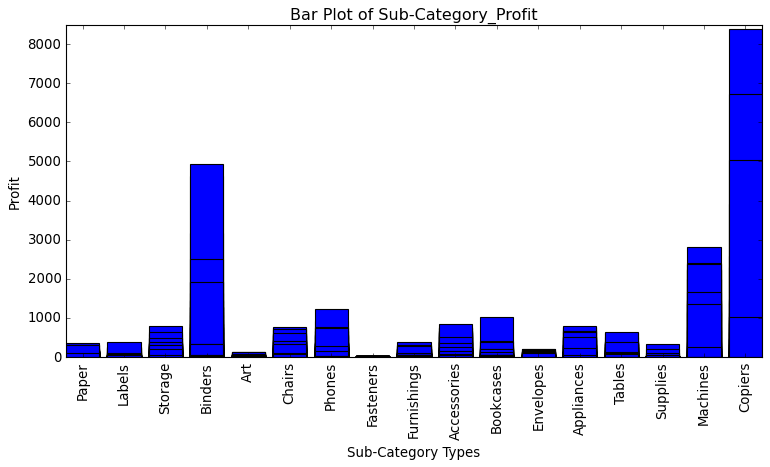

```python
plt.figure(figsize=(10,5))
from matplotlib import style
style.use('classic')
plt.bar(data['Sub-Category'], data['Profit'])
plt.ylim(0,8500)
plt.title('Bar Plot of Sub-Category_Profit')
plt.xlabel('Sub-Category Types')
plt.ylabel('Profit')
plt.xticks(rotation=90)
plt.show()
```

Copiers sub-category is producing the Highest Profit than all the other, in spite of its low sold quantity.

```python
data['Product Name'].value_counts()
```

```
Staple envelope                                                          48
Easy-staple paper                                                        46
Staples                                                                  46
Avery Non-Stick Binders                                                  20
Staples in misc. colors                                                  19
                                                                         ..
Plantronics Single Ear Headset                                            1
Cisco SPA525G2 5-Line IP Phone                                            1
Canon imageCLASS MF7460 Monochrome Digital Laser Multifunction Copier     1
Avery 484                                                                 1
Acco Glide Clips                                                          1
Name: Product Name, Length: 1850, dtype: int64
```

## Product with highest demand in each segment

```python
Product_Segment = data.groupby(['Segment', 'Product Name'])['Quantity'].sum().sort_values(ascending = False)
Product_Segment = Product_Segment.to_frame(name='Quantity').reset_index()
z = Product_Segment.groupby(['Segment']).head(1)
```

```python
z.head()
```

|  | Segment | Product Name | Quantity |
| --- | --- | --- | --- |
| 0 | Consumer | Staple envelope | 104 |
| 2 | Corporate | Staples | 90 |
| 10 | Home Office | Easy-staple paper | 46 |

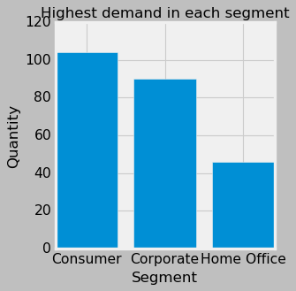

```python
plt.figure(figsize=(4,4))
from matplotlib import style

style.use('fivethirtyeight')
plt.bar(z['Segment'], z['Quantity'])

plt.title('Highest demand in each segment', fontsize = 15)
plt.xlabel('Segment', fontsize = 15)
plt.ylabel('Quantity', fontsize = 15)
plt.show()
```

## Category of the product with highest demand in each region

```python
Category_Region= data.groupby(['Region', 'Category'])['Quantity'].sum().sort_values(ascending = False)
Category_Region = Category_Region.to_frame(name='Quantity').reset_index()
x = Category_Region.groupby(['Region']).head(1)
```

```python
x.head()
```

|  | Region | Category | Quantity |
| --- | --- | --- | --- |
| 0 | West | Office Supplies | 7235 |
| 1 | East | Office Supplies | 6462 |
| 2 | Central | Office Supplies | 5409 |
| 3 | South | Office Supplies | 3800 |

Noticed that the product category 'Office Supplies' has the highest demand in all the regions.

```python
Category_Region1= data.groupby(['Region', 'Category'])['Sales'].sum().sort_values(ascending = False)
Category_Region1 = Category_Region1.to_frame(name='Sales').reset_index()
sales = Category_Region1.groupby(['Region']).head(1)
sales.head()
```

|  | Region | Category | Sales |
| --- | --- | --- | --- |
| 0 | East | Technology | 264973.9810 |
| 1 | West | Furniture | 252612.7435 |
| 6 | Central | Technology | 170416.3120 |
| 9 | South | Technology | 148771.9080 |

Noticed that the product category 'Technology' generates the highest revenue in the regions 'East', 'Central' and 'South'. The product category 'Furniture' generates the highest revenue in the west region.

```python
SubCategory_Region= data.groupby(['Region', 'Sub-Category'])['Quantity'].sum().sort_values(ascending = False)
SubCategory_Region = SubCategory_Region.to_frame(name='Quantity').reset_index()
s = SubCategory_Region.groupby(['Region']).head(1)
s.head()
```

|  | Region | Sub-Category | Quantity |
| --- | --- | --- | --- |
| 0 | West | Binders | 1868 |
| 2 | East | Binders | 1652 |
| 3 | Central | Binders | 1473 |
| 12 | South | Binders | 981 |

Noticed that the product sub-category 'Binders' has the highest demand in all the regions.

```python
SubCategory_Region1= data.groupby(['Region', 'Sub-Category'])['Sales'].sum().sort_values(ascending = False)
SubCategory_Region1 = SubCategory_Region1.to_frame(name='Sales').reset_index()
sales1 = SubCategory_Region1.groupby(['Region']).head(1)
sales1.head()
```

|  | Region | Sub-Category | Sales |
| --- | --- | --- | --- |
| 0 | West | Chairs | 101781.328 |
| 1 | East | Phones | 100614.982 |
| 4 | Central | Chairs | 85230.646 |
| 11 | South | Phones | 58304.438 |

Noticed that the product sub-category 'Phones' generates the highest revenue in the regions 'East' and 'South'. The product sub-category 'Chairs' generates the highest revenue in the regions 'Central' ad 'West'.

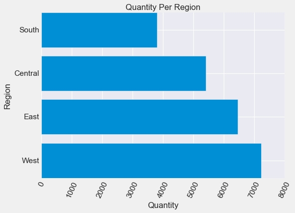

```python
plt.figure(figsize=(7,5))
from matplotlib import style
style.use('seaborn-darkgrid')
plt.barh(x['Region'], x['Quantity'])

plt.title('Quantity Per Region', fontsize = 15)
plt.xlabel('Quantity',fontsize = 15 )
plt.ylabel('Region',fontsize = 15)
plt.xticks(rotation=65)
plt.show()
```

## The category of the product which is being sold with highest discounts

```python
data['Discount Amt']=data['Discount']*data['Sales']/(1-data['Discount'])
```

```python
Category_Discount = data.groupby(['Category'])['Discount Amt'].sum().sort_values(ascending = False)
Category_Discount= Category_Discount.to_frame(name='Discount').reset_index()
y = Category_Discount.head(1)
```

```python
y.head()
```

|  | Category | Discount |
| --- | --- | --- |
| 0 | Technology | 202258.087 |

The product category 'Technology' is being sold with highest discounts.

```python
Category_Discount1 = data.groupby(['Category', 'Product Name'])['Discount Amt'].sum().sort_values(ascending = False)
Category_Discount1= Category_Discount1.to_frame(name='Discount').reset_index()
xx = Category_Discount1.groupby('Category').head(1)
```

```python
xx.head()
```

|  | Category | Product Name | Discount |
| --- | --- | --- | --- |
| 0 | Technology | Cisco TelePresence System EX90 Videoconferenci... | 22638.4800 |
| 1 | Office Supplies | GBC DocuBind P400 Electric Binding System | 18781.6620 |
| 10 | Furniture | Riverside Palais Royal Lawyers Bookcase, Royal... | 5532.5544 |

Product with Highest offered Discount in each category.

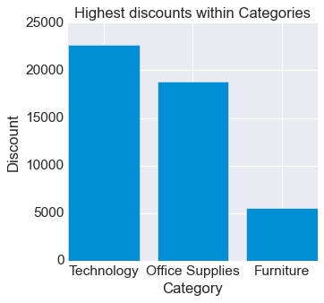

```python
plt.figure(figsize=(4,4))
from matplotlib import style
# style.use('Solarize_Light2')
plt.bar(xx['Category'], xx['Discount'])

plt.title('Highest discounts within Categories', fontsize = 15)
plt.xlabel('Category', fontsize = 15)
plt.ylabel('Discount', fontsize = 15)
plt.show()
```

## Most Used Ship Mode

```python
data['Ship Mode'].value_counts()
```

```
Standard Class    5966
Second Class      1946
First Class       1539
Same Day           543
Name: Ship Mode, dtype: int64
```

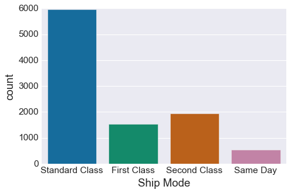

```python
plt.figure(figsize=(6,4))
from matplotlib import style
style.use('seaborn-colorblind')
sn.countplot(data['Ship Mode'])
```

Standard Class is the most popular SHIP-MODE used by the customers.

[output not shown]

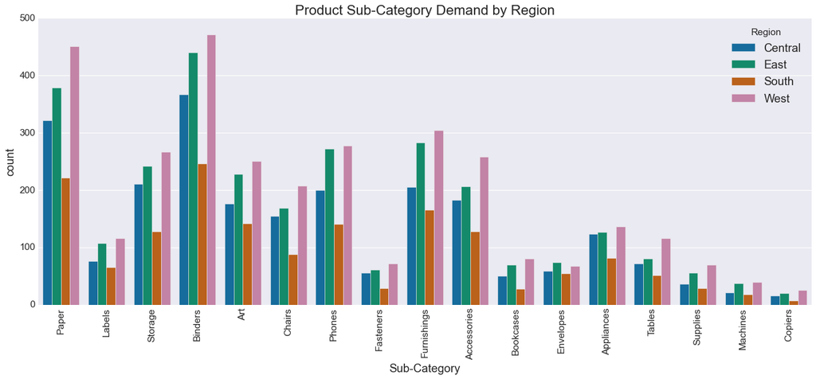

```python
plt.figure(figsize=(18,7))
style.use('seaborn-darkgrid')
sn.countplot(data['Sub-Category'], hue=data.Region)
plt.title('Product Sub-Category Demand by Region')
plt.xticks(rotation=90)
```

## Impact of Discount on Profit%

```python
x=data['Sales']
y=data['Profit']
b=[]
for j in range(len(x)):
    q=round(y[j]*100/(x[j]-y[j]),2)
    b.append(q)
data['Profit%']=b
```

```python
st.shapiro(data['Profit%'])
```

```
ShapiroResult(statistic=0.9671892523765564, pvalue=1.1462621438177004e-42)
```

```python
st.shapiro(data['Discount Amt'])
```

```
ShapiroResult(statistic=0.10927116870880127, pvalue=0.0)
```

```python
st.levene(data['Discount Amt'],data['Profit%'])
```

```
LeveneResult(statistic=42.96100965156526, pvalue=5.72048573689252e-11)
```

```python
#As discount and profit% do not follow normal distribution -> Non-Parametric
st.spearmanr(data['Discount Amt'],data['Profit%'])
```

```
SpearmanrResult(correlation=-0.007070027383107432, pvalue=0.4797460735315925)
```

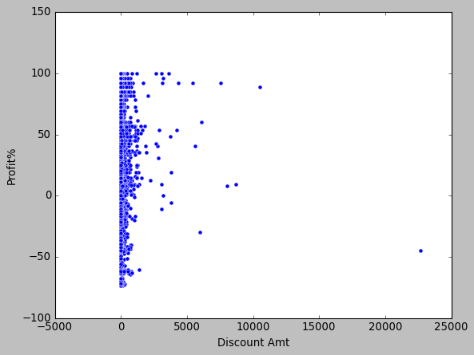

```python
from matplotlib import style
style.use('classic')
sn.scatterplot(data['Discount Amt'], data['Profit%'])
```

```python
dx = data.groupby('Region').agg({'Sales':'sum','Profit':'sum','Quantity':'sum','Discount Amt':'sum'}).reset_index()
# data.groupby('Region').agg({'Sales':'sum'}).reset_index()

dx['% sales'] = dx['Sales']/sum(dx['Sales'])
dx['% profit'] = dx['Profit']/sum(dx['Profit'])
dx['% quantity'] = dx['Quantity']/sum(dx['Quantity'])
dx['% discount'] = dx['Discount Amt']/sum(dx['Discount Amt'])
# dx['% sales'] = dx['Sales']/sum(dx['Sales'])
dx = dx[['Region','% sales','% profit','% quantity']]
```

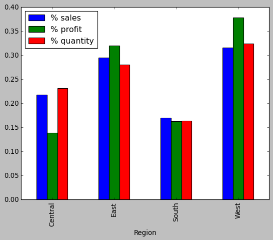

```python
dx.plot(x="Region", y=["% sales", "% profit", "% quantity"], kind="bar")
```

## Which Sub-Category should be focused?

[output not shown]

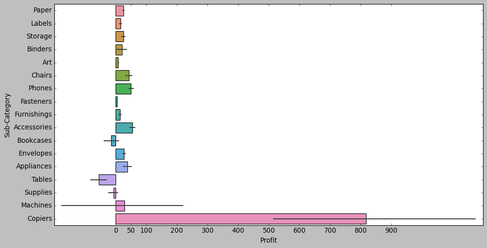

```python
#1. Profit produced by Sub-Catgeory
plt.figure(figsize=(15,6))
xdata=(0,50,100,200,300,400,500,600,700,800,900)
plt.figure(figsize=(14,7))
sn.barplot(y=data['Sub-Category'], x=data['Profit'])
plt.xticks(xdata)
```

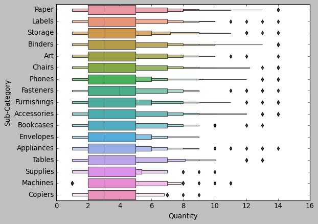

```python
#2. Quantity purchased by product.


sn.boxenplot(y='Sub-Category', x ='Quantity', data=data)
```

Though the profit for'Copiers' is high but quantity purchased is low. hence, supply for these product need to be increased.

## Which state should be chosen for expansion & which products should be focused?

[output not shown]

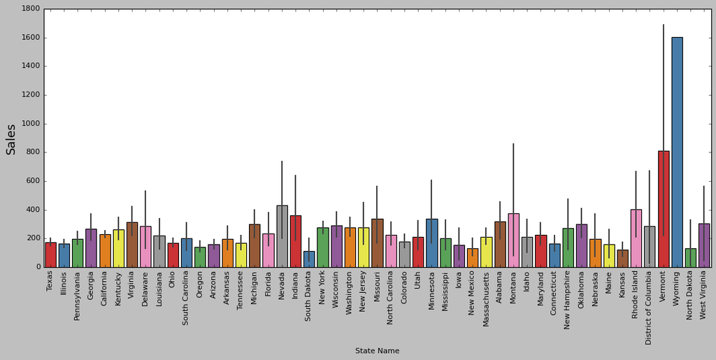

```python
plt.figure(figsize=(16,6))
sn.barplot(data['State'],data['Sales'], palette='Set1')
plt.xlabel('State Name', fontsize='10')
plt.xticks(fontsize='10', rotation=90)
plt.ylabel('Sales', fontsize='16')
plt.yticks(fontsize='10')
```

[output not shown]

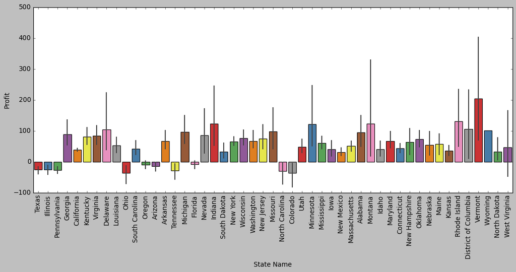

```python
plt.figure(figsize=(16,6))
sn.barplot(data['State'],data['Profit'], palette='Set1')
plt.xlabel('State Name', fontsize='12')
plt.xticks(fontsize='12', rotation=90)
plt.ylabel('Profit', fontsize='12')
plt.yticks(fontsize='12')
```

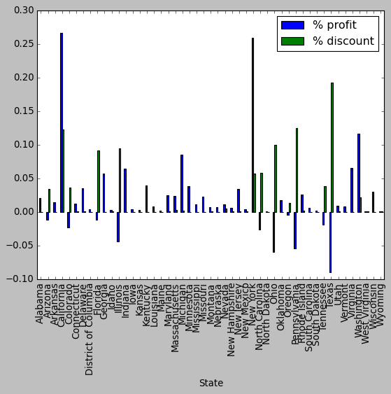

```python
plt.figure(figsize=(16,6))
dy = data.groupby('State').agg({'Profit':'sum','Discount Amt':'sum'}).reset_index()
dy['% profit'] = dy['Profit']/sum(dy['Profit'])
dy['% discount'] = dy['Discount Amt']/sum(dy['Discount Amt'])
dy = dy[['State','% profit','% discount']]
dy.plot(x="State", y=["% profit", "% discount"], kind="bar")
```

# Sales/Profit Analysis:

## Sales by Year

```python
data['Order Year']=pd.DatetimeIndex(data['Order Date']).year.astype(str)
data.head()
```

|  | Row ID | Order ID | Order Date | Ship Date | Ship Mode | Customer ID | Customer Name | Segment | City | State | ... | Category | Sub-Category | Product Name | Sales | Quantity | Discount | Profit | Discount Amt | Profit% | Order Year |
| --- | --- | --- | --- | --- | --- | --- | --- | --- | --- | --- | --- | --- | --- | --- | --- | --- | --- | --- | --- | --- | --- |
| 7980 | 7981 | CA-2011-103800 | 2011-01-04 | 2011-01-08 | Standard Class | DP-13000 | Darren Powers | Consumer | Houston | Texas | ... | Office Supplies | Paper | Message Book, Wirebound, Four 5 1/2" X 4" Form... | 16.448 | 2 | 0.2 | 5.5512 | 4.112 | 19.05 | 2011 |
| 739 | 740 | CA-2011-112326 | 2011-01-05 | 2011-01-09 | Standard Class | PO-19195 | Phillina Ober | Home Office | Naperville | Illinois | ... | Office Supplies | Labels | Avery 508 | 11.784 | 3 | 0.2 | 4.2717 | 2.946 | 42.86 | 2011 |
| 740 | 741 | CA-2011-112326 | 2011-01-05 | 2011-01-09 | Standard Class | PO-19195 | Phillina Ober | Home Office | Naperville | Illinois | ... | Office Supplies | Storage | SAFCO Boltless Steel Shelving | 272.736 | 3 | 0.2 | -64.7748 | 68.184 | 88.68 | 2011 |
| 741 | 742 | CA-2011-112326 | 2011-01-05 | 2011-01-09 | Standard Class | PO-19195 | Phillina Ober | Home Office | Naperville | Illinois | ... | Office Supplies | Binders | GBC Standard Plastic Binding Systems Combs | 3.540 | 2 | 0.8 | -5.4870 | 14.160 | -28.57 | 2011 |
| 1759 | 1760 | CA-2011-141817 | 2011-01-06 | 2011-01-13 | Standard Class | MB-18085 | Mick Brown | Consumer | Philadelphia | Pennsylvania | ... | Office Supplies | Art | Avery Hi-Liter EverBold Pen Style Fluorescent ... | 19.536 | 3 | 0.2 | 4.8840 | 4.884 | 12.68 | 2011 |

5 rows × 22 columns

```python
s=data.groupby(by=['Order Year'], as_index=False)['Sales'].sum().head()
s
```

|  | Order Year | Sales |
| --- | --- | --- |
| 0 | 2011 | 484247.4981 |
| 1 | 2012 | 470532.5090 |
| 2 | 2013 | 608473.8300 |
| 3 | 2014 | 733947.0232 |

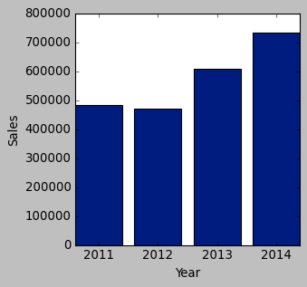

```python
plt.figure(figsize=(4,4))
from matplotlib import style
style.use('seaborn-dark-palette')
plt.bar(s['Order Year'], s['Sales'])

plt.xlabel('Year')
plt.ylabel('Sales')
plt.show()
```

Noticed the increased trend in sales, year by year from 2011 to 2014 but slightly decreased in 2012.

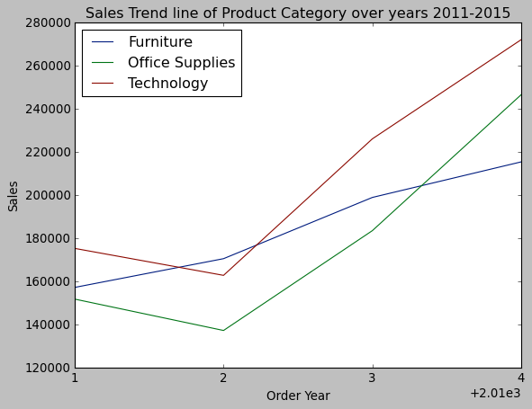

```python
data['Order Year']=data['Order Year'].astype(int)
a5=data.groupby(['Order Year','Category'])['Sales'].sum()
a5=a5.to_frame(name='Sales').reset_index()
sn.lineplot(x='Order Year', y='Sales', hue='Category', data=a5)
plt.xticks(np.arange(2011,2015,1))
plt.title('Sales Trend line of Product Category over years 2011-2015')
plt.legend(loc='upper left')
plt.show()
```

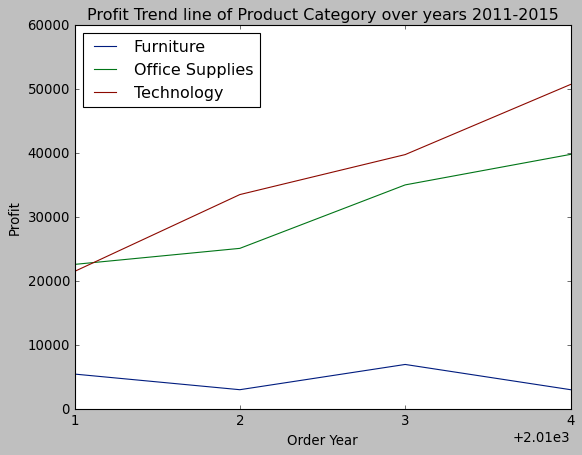

```python
a6=data.groupby(['Order Year','Category'])['Profit'].sum()
a6=a6.to_frame(name='Profit').reset_index()
sn.lineplot(x='Order Year', y='Profit', hue='Category', data=a6)
plt.xticks(np.arange(2011,2015,1))
plt.title('Profit Trend line of Product Category over years 2011-2015')
plt.legend(loc='upper left')
plt.show()
```

# The TOP 5 customers with most number of orders:

```python
data.groupby(by=['Customer ID', 'Region'], as_index=False)['Order ID'].count().head()
```

|  | Customer ID | Region | Order ID |
| --- | --- | --- | --- |
| 0 | AA-10315 | Central | 6 |
| 1 | AA-10315 | East | 2 |
| 2 | AA-10315 | West | 3 |
| 3 | AA-10375 | Central | 2 |
| 4 | AA-10375 | East | 5 |

```python
orders=data.groupby(by=['Customer ID', 'Region'], as_index=False)['Order ID'].count()
```

```python
print('The TOP 5 customers with most number of orders:')
orders.sort_values(by='Order ID', ascending=False).head()
```

```
The TOP 5 customers with most number of orders:
```

|  | Customer ID | Region | Order ID |
| --- | --- | --- | --- |
| 2274 | SV-20365 | East | 26 |
| 2483 | WB-21850 | West | 24 |
| 141 | AP-10915 | West | 23 |
| 2079 | RW-19540 | West | 19 |
| 2307 | TB-21055 | East | 18 |

# The TOP 5 customers with highest amount spent:

```python
amount_spent =data.groupby(by=['Customer ID', 'Region'], as_index=False)['Sales'].sum()
```

```python
print('The TOP 5 customers with highest amount spent:')
amount_spent.sort_values(by='Sales', ascending=False).head()
```

```
The TOP 5 customers with highest amount spent:
```

|  | Customer ID | Region | Sales |
| --- | --- | --- | --- |
| 2207 | SM-20320 | South | 23669.196 |
| 2337 | TC-20980 | Central | 18437.138 |
| 1961 | RB-19360 | West | 14345.276 |
| 2306 | TA-21385 | East | 13723.498 |
| 20 | AB-10105 | Central | 12181.594 |

```python
group_country_orders=data.groupby('State')['Order ID'].count().sort_values()
```

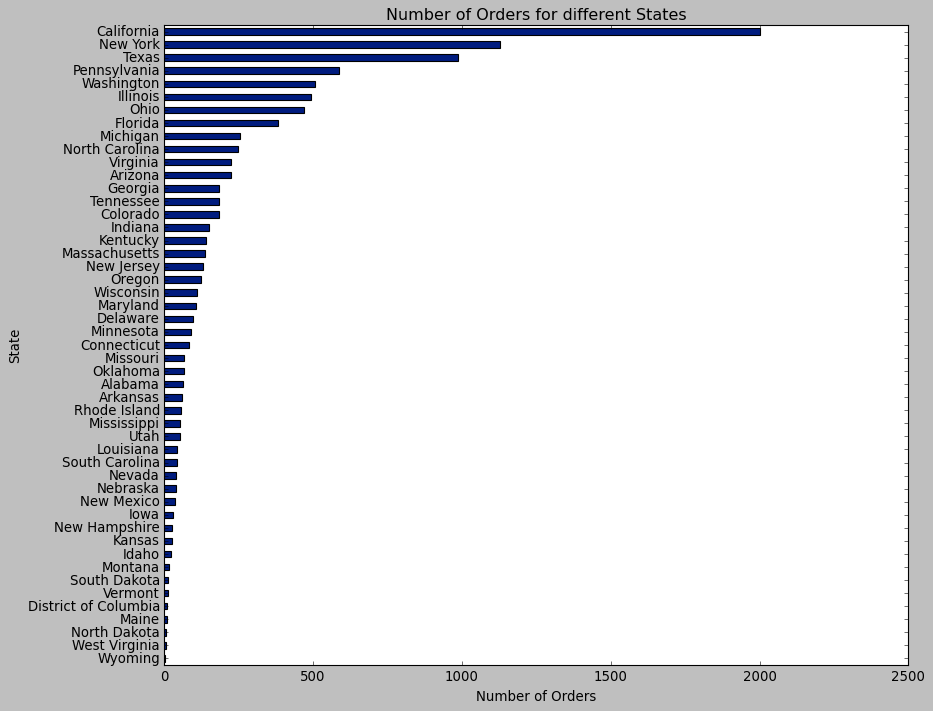

```python
plt.subplots(figsize=(12,10))
group_country_orders.plot(kind='barh', fontsize=12)
plt.title('Number of Orders for different States')
plt.xlabel('Number of Orders', fontsize=12)
plt.ylabel('State', fontsize=12)
plt.show()
```

California has the highest number of orders.

## The category of the product that earns highest profit

```python
Category_Profit= round((data.groupby(['Category'])['Profit'].sum().sort_values(ascending = False)),2)
Category_Profit = Category_Profit.to_frame(name='Profit').reset_index()
Category_Profit_Analysis = Category_Profit.groupby(['Category']).head(1)
Category_Profit_Analysis
```

|  | Category | Profit |
| --- | --- | --- |
| 0 | Technology | 145454.95 |
| 1 | Office Supplies | 122490.80 |
| 2 | Furniture | 18451.27 |

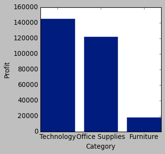

```python
plt.subplots(figsize=(4,4))
from matplotlib import style
style.use('fivethirtyeight')
plt.bar(Category_Profit_Analysis['Category'], Category_Profit_Analysis['Profit'])
plt.xlabel('Category')
plt.ylabel('Profit')
plt.show()
```

- Technology Category produced the Highest Profit than all other

## Most valuable customer

```python
Customer_Profit= round((data.groupby(['Customer Name','Category'])['Profit'].sum().sort_values(ascending = False)),2)
Customer_Profit = Customer_Profit.to_frame(name='Profit').reset_index()
Customer_Profit_Analysis_count = Customer_Profit.groupby(['Customer Name']).head(1)
Customer_Profit_Analysis_count.head()
```

|  | Customer Name | Category | Profit |
| --- | --- | --- | --- |
| 0 | Tamara Chand | Technology | 8584.24 |
| 1 | Raymond Buch | Technology | 6777.52 |
| 2 | Sanjit Chand | Office Supplies | 5654.87 |
| 3 | Adrian Barton | Office Supplies | 5353.28 |
| 4 | Hunter Lopez | Technology | 5345.42 |

Most valuable customer is Tamara Chand in Technology Category

## The segment which yields highest profit

```python
Segment_Profit= round((data.groupby(['Segment'])['Profit'].sum().sort_values(ascending = False)),2)
Segment_Profit = Segment_Profit.to_frame(name='Profit').reset_index()
Segment_Profit_Analysis_Sum = Segment_Profit.groupby(['Segment']).head(1)
Segment_Profit_Analysis_Sum
```

|  | Segment | Profit |
| --- | --- | --- |
| 0 | Consumer | 134119.21 |
| 1 | Corporate | 91979.13 |
| 2 | Home Office | 60298.68 |

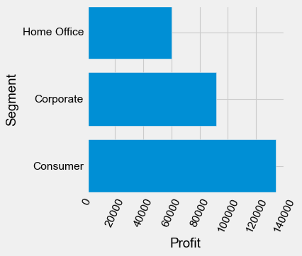

```python
plt.subplots(figsize=(4,4))
from matplotlib import style
style.use('seaborn-darkgrid')
plt.barh(Segment_Profit_Analysis_Sum['Segment'], Segment_Profit_Analysis_Sum['Profit'])
plt.xlabel('Profit')
plt.ylabel('Segment')
plt.xticks(rotation=65)
plt.show()
```

Consumer Segment has yielded highest profit

## Top & Bottom 5 States based on Profit%

```python
State_Top5= data.groupby('State').agg({'Sales':'sum','Profit':'sum','Profit%':'mean'}).sort_values(by='Profit%',ascending = False).reset_index()
State_Top5.head()
```

|  | State | Sales | Profit | Profit% |
| --- | --- | --- | --- | --- |
| 0 | North Dakota | 919.910 | 230.1497 | 74.264286 |
| 1 | Idaho | 4382.486 | 826.7231 | 53.432381 |
| 2 | Montana | 5589.352 | 1833.3285 | 53.420667 |
| 3 | Nevada | 16729.102 | 3316.7659 | 42.179487 |
| 4 | Iowa | 4579.760 | 1183.8119 | 42.179000 |

```python
State_Bottom5=State_Top5= data.groupby('State').agg({'Sales':'sum','Profit':'sum','Profit%':'mean'}).sort_values(by='Profit%').reset_index()
State_Bottom5.head()
```

|  | State | Sales | Profit | Profit% |
| --- | --- | --- | --- | --- |
| 0 | Wyoming | 1603.136 | 100.1960 | -44.440000 |
| 1 | Kansas | 2914.310 | 836.4435 | 9.018333 |
| 2 | West Virginia | 1209.824 | 185.9216 | 11.617500 |
| 3 | Vermont | 8929.370 | 2244.9783 | 13.289091 |
| 4 | Utah | 11220.056 | 2546.5335 | 17.627358 |

## City with highest sales and Profit

```python
City_Sales= round((data.groupby(['City'])['Sales'].sum().sort_values(ascending = False)),2)
City_Sales = City_Sales.to_frame(name='Sales').reset_index()
City_Sales_Sum = City_Sales.groupby(['City']).head(1)
City_Sales_Sum.head()
```

|  | City | Sales |
| --- | --- | --- |
| 0 | New York City | 256368.16 |
| 1 | Los Angeles | 175851.34 |
| 2 | Seattle | 119540.74 |
| 3 | San Francisco | 112669.09 |
| 4 | Philadelphia | 109077.01 |

```python
City_Profit= data.groupby(['City'])['Profit'].sum().sort_values(ascending = False)
City_Profit = City_Profit.to_frame(name='Profit').reset_index()
City_Profit_Sum = City_Profit.groupby(['City']).head(1)
City_Profit_Sum.head()
```

|  | City | Profit |
| --- | --- | --- |
| 0 | New York City | 62036.9837 |
| 1 | Los Angeles | 30440.7579 |
| 2 | Seattle | 29156.0967 |
| 3 | San Francisco | 17507.3854 |
| 4 | Detroit | 13181.7908 |

INFERENCE:

- New York city has highest Sales
- New York city has highest Profit too among other cities

## Poduct Categories that made loss

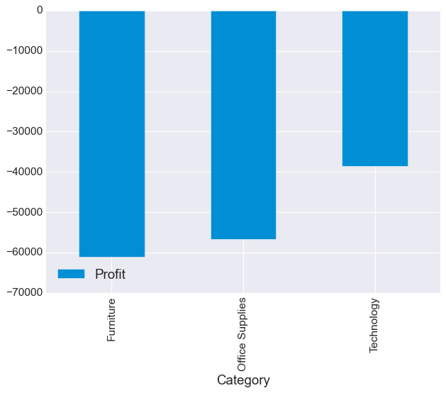

```python
neg = data[(data['Profit']<0)]
neg.groupby('Category').sum().plot(kind='bar',y='Profit')
plt.show()
```

INFERENCE:

- Furniture category products had made the highest loss accounting to -60936

## Product Sub-Categories that made loss

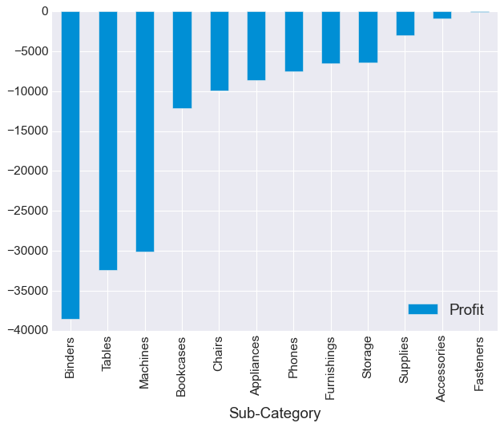

```python
neg.groupby('Sub-Category').sum().sort_values(by='Profit').plot(kind='bar',y='Profit')
plt.show()
```

Binders sub-category products had made the highest loss.

## Predictive analytics

#### As the data contains various metrics related to sales like orders, categories, sub categories, sales etc amd the quantity is a continuous metric, In this scenario we are taking the quantity as the target variable and predict it using various features. This is clearly a regression problem

### XGBoost Model

```python
X = data.drop(['Quantity'], axis=1)
X = pd.get_dummies(X) #Converting categorical values to numeric
y = data['Quantity']
# print(X)
```

```python
data['Order Date']=data['Order Date'].astype(str)
data['Ship Date']=data['Ship Date'].astype(str)
```

```python
# Train Test Split
X_train, X_test, y_train, y_test = train_test_split(X, y, test_size=0.2, random_state=42)
```

```python
# Model Training
model = xgb.XGBRegressor(n_estimators=1000, learning_rate=0.1, max_depth=10, reg_alpha=0.1, reg_lambda=0.1, random_state=42)
print('fitting started')
model.fit(X_train, y_train)
print('fitting done')
```

```
fitting started
fitting done
```

```python
# Model Evaluation
y_pred = model.predict(X_test)
pred_vs_actual = pd.DataFrame({'Actual': y_test.squeeze(), 'Predicted': y_pred.squeeze()})
pred_vs_actual = pred_vs_actual.round(3)
```

```python
pred_vs_actual
```

|  | Actual | Predicted |
| --- | --- | --- |
| 3818 | 7 | 5.310 |
| 9228 | 4 | 3.339 |
| 5889 | 2 | 3.205 |
| 5462 | 10 | 4.925 |
| 7774 | 3 | 2.117 |
| ... | ... | ... |
| 7484 | 1 | 1.411 |
| 4446 | 4 | 4.287 |
| 2612 | 3 | 2.869 |
| 2509 | 6 | 4.221 |
| 1673 | 2 | 4.126 |

1999 rows × 2 columns

### Evaluating the model using MAE(Mean Average Error), MSE(Mean Squared Error), (Coefficient of Determination)R2, MAPE(Mean Absolute Percentage Error)

#### MAE: It is the mean of the errors between between the actual and predicted values

#### MSE: It is the mean of the squares of difference between the actual and predicted values

#### R2-Score: It is a metric representing the determination coefficient, it usually ranges between 0 and 1 where 1 being the heighest accuracy

#### MAPE: It is the percentage of mean of absolute errors between the actual and predicted values

```python
print('MAE:', mean_absolute_error(y_test, y_pred))
print('MSE:', mean_squared_error(y_test, y_pred))
print('R2:', r2_score(y_test, y_pred))
print('MAPE:', mean_absolute_percentage_error(y_test, y_pred))
```

[output not shown]

#### This shows that the model is performing with an avccuracy close to 68% as the mape score is 0.32 i.e 32% error

### Random Forest Regression Model

```python
rf_regressor = RandomForestRegressor(n_estimators=100, max_depth=10)
print('fitting started')
rf_regressor.fit(X_train, y_train)
print('fitting done')
```

```
fitting started
fitting done
```

```python
y_pred = rf_regressor.predict(X_test)
pred_vs_actual = pred_vs_actual.round(3)
pred_vs_actual = pd.DataFrame({'Actual': y_test.squeeze(), 'Predicted': y_pred.squeeze()})
```

```python
pred_vs_actual
```

|  | Actual | Predicted |
| --- | --- | --- |
| 3818 | 7 | 5.198785 |
| 9228 | 4 | 2.459639 |
| 5889 | 2 | 4.102827 |
| 5462 | 10 | 4.793361 |
| 7774 | 3 | 2.093420 |
| ... | ... | ... |
| 7484 | 1 | 1.225752 |
| 4446 | 4 | 4.415674 |
| 2612 | 3 | 2.436068 |
| 2509 | 6 | 4.664159 |
| 1673 | 2 | 4.861896 |

1999 rows × 2 columns

```python
print('MAE:', mean_absolute_error(y_test, y_pred))
print('MSE:', mean_squared_error(y_test, y_pred))
print('R2:', r2_score(y_test, y_pred))
print('MAPE:', mean_absolute_percentage_error(y_test, y_pred))
```

```
MAE: 1.407536542585985
MSE: 3.5753399055724095
R2: 0.25284665197535083
MAPE: 0.4968897516534939
```

#### These models can further be improved by tuning the hyper parameters using grid search CV with helps in finding the optimal parameters and getting the best accuracies.